# project

2023-11-14

```r
training_data <- arrow::read_parquet("training_data.parquet")
head(training_data)
```

```
##     price        state        bed_vs_bath house_size_filled_capped
## 1  395000   New Jersey bed_less_than_bath                 2049.718
## 2  325000  Connecticut bed_less_than_bath                 1992.000
## 3 1450000     New York     bed_equal_bath                 1186.000
## 4  275000  Connecticut     bed_equal_bath                 1442.000
## 5  425000 Rhode Island bed_more_than_bath                 6798.000
## 6 1075000     New York bed_more_than_bath                 1890.000
##   bed_filled_capped bath_filled_capped acre_lot_filled_capped
## 1                 2                  3               10.88983
## 2                 2                  3               10.88983
## 3                 2                  2               10.88983
## 4                 2                  2                0.37000
## 5                 8                  4                0.11000
## 6                 4                  3                0.09000
##   bed/house_size_filled_capped bath/house_size_filled_capped year month
```

[output cut: 20 more lines]

```r
summary(training_data)
```

```
##      price              state           bed_vs_bath
##  Min.   :    21000   Length:262889      Length:262889
##  1st Qu.:   315000   Class :character   Class :character
##  Median :   499000   Mode  :character   Mode  :character
##  Mean   :   832282
##  3rd Qu.:   829900
##  Max.   :875000000
##  house_size_filled_capped bed_filled_capped bath_filled_capped
##  Min.   : 500             Min.   :1.000     Min.   :1.00
##  1st Qu.:1315             1st Qu.:2.000     1st Qu.:2.00
##  Median :2050             Median :3.000     Median :2.00
##  Mean   :1985             Mean   :3.232     Mean   :2.39
##  3rd Qu.:2050             3rd Qu.:4.000     3rd Qu.:3.00
##  Max.   :7000             Max.   :8.000     Max.   :7.00
##  acre_lot_filled_capped bed/house_size_filled_capped
##  Min.   : 0.010         Min.   :0.0001429
##  1st Qu.: 0.130         1st Qu.:0.0013471
##  Median : 0.440         Median :0.0016630
##  Mean   : 3.703         Mean   :0.0017977
##  3rd Qu.:10.890         3rd Qu.:0.0021583
##  Max.   :17.000         Max.   :0.0087500
##  bath/house_size_filled_capped      year          month
##  Min.   :0.0001429             Min.   :1985   Min.   : 1.000
##  1st Qu.:0.0009757             1st Qu.:2003   1st Qu.: 4.000
##  Median :0.0012330             Median :2010   Median : 7.000
##  Mean   :0.0012886             Mean   :2009   Mean   : 6.734
##  3rd Qu.:0.0015385             3rd Qu.:2017   3rd Qu.:10.000
##  Max.   :0.0080000             Max.   :2023   Max.   :12.000
##  bed/acre_lot_filled_capped bath/acre_lot_filled_capped
##  Min.   :  0.0588           Min.   :  0.0588
##  1st Qu.:  0.2755           1st Qu.:  0.2755
##  Median :  7.8431           Median :  5.2632
##  Mean   : 22.0851           Mean   : 15.2288
##  3rd Qu.: 27.2727           3rd Qu.: 17.6471
##  Max.   :800.0000           Max.   :600.0000
##  house_size/acre_lot_filled_capped __index_level_0__
##  Min.   :    29.4                  Min.   : 24237
##  1st Qu.:   188.2                  1st Qu.:326235
##  Median :  4455.9                  Median :546259
##  Mean   : 11907.2                  Mean   :514001
##  3rd Qu.: 14640.8                  3rd Qu.:716799
##  Max.   :350000.0                  Max.   :904957
```

```r
n = nrow(training_data)
```

1.Using the raw variable

```r
columns_to_keep1 <- c("price","year","state","month","house_size_filled_capped","bed_filled_capped","bath_filled_capped","acre_lot_filled_capped")
training_data_selected1<- training_data[,columns_to_keep1]
head(training_data_selected1)
```

```
##     price year        state month house_size_filled_capped bed_filled_capped
## 1  395000 2017   New Jersey    12                 2049.718                 2
## 2  325000 2015  Connecticut     9                 1992.000                 2
## 3 1450000 2014     New York    10                 1186.000                 2
## 4  275000 2021  Connecticut     5                 1442.000                 2
## 5  425000 2008 Rhode Island     1                 6798.000                 8
## 6 1075000 1994     New York    12                 1890.000                 4
##   bath_filled_capped acre_lot_filled_capped
## 1                  3               10.88983
## 2                  3               10.88983
## 3                  2               10.88983
## 4                  2                0.37000
## 5                  4                0.11000
## 6                  3                0.09000
```

```r
summary(training_data_selected1)
```

```
##      price                year         state               month
##  Min.   :    21000   Min.   :1985   Length:262889      Min.   : 1.000
##  1st Qu.:   315000   1st Qu.:2003   Class :character   1st Qu.: 4.000
##  Median :   499000   Median :2010   Mode  :character   Median : 7.000
##  Mean   :   832282   Mean   :2009                      Mean   : 6.734
##  3rd Qu.:   829900   3rd Qu.:2017                      3rd Qu.:10.000
##  Max.   :875000000   Max.   :2023                      Max.   :12.000
##  house_size_filled_capped bed_filled_capped bath_filled_capped
##  Min.   : 500             Min.   :1.000     Min.   :1.00
##  1st Qu.:1315             1st Qu.:2.000     1st Qu.:2.00
##  Median :2050             Median :3.000     Median :2.00
##  Mean   :1985             Mean   :3.232     Mean   :2.39
##  3rd Qu.:2050             3rd Qu.:4.000     3rd Qu.:3.00
##  Max.   :7000             Max.   :8.000     Max.   :7.00
##  acre_lot_filled_capped
##  Min.   : 0.010
##  1st Qu.: 0.130
##  Median : 0.440
##  Mean   : 3.703
##  3rd Qu.:10.890
##  Max.   :17.000
```

2 linear regression

```r
#Convert state to factor type
training_data_selected1$state <- as.factor(training_data_selected1$state)
training_data_selected1$month <- as.factor(training_data_selected1$month)

selected_model1<-lm(price ~ .,data=training_data_selected1)
summary(selected_model1)
```

```
##
## Call:
## lm(formula = price ~ ., data = training_data_selected1)
##
## Residuals:
##       Min        1Q    Median        3Q       Max
##  -3764409   -449198    -78393    260024 873343883
##
## Coefficients:
##                            Estimate Std. Error t value Pr(>|t|)
## (Intercept)              -3.645e+06  1.211e+06  -3.009  0.00262 **
## year                      1.245e+03  6.021e+02   2.067  0.03872 *
## stateMaine                4.475e+04  5.118e+04   0.874  0.38190
## stateMassachusetts        4.456e+05  2.043e+04  21.811  < 2e-16 ***
## stateNew Hampshire        3.104e+04  3.466e+04   0.896  0.37044
## stateNew Jersey           8.863e+04  1.764e+04   5.025 5.04e-07 ***
## stateNew York             9.345e+05  1.910e+04  48.926  < 2e-16 ***
## statePennsylvania         1.583e+05  3.594e+04   4.403 1.07e-05 ***
## stateRhode Island         1.468e+05  3.291e+04   4.461 8.17e-06 ***
## stateVermont             -1.587e+05  3.772e+04  -4.207 2.59e-05 ***
## month2                   -8.654e+04  2.876e+04  -3.009  0.00262 **
## month3                   -2.217e+04  2.761e+04  -0.803  0.42202
## month4                   -1.514e+04  2.750e+04  -0.550  0.58202
## month5                    2.713e+03  2.699e+04   0.101  0.91993
## month6                   -2.722e+04  2.610e+04  -1.043  0.29685
## month7                   -1.050e+04  2.592e+04  -0.405  0.68533
## month8                   -3.711e+04  2.596e+04  -1.429  0.15287
## month9                   -1.580e+04  2.666e+04  -0.592  0.55353
## month10                  -2.274e+04  2.645e+04  -0.860  0.39002
## month11                  -2.011e+04  2.727e+04  -0.737  0.46085
## month12                   4.702e+04  2.672e+04   1.760  0.07846 .
## house_size_filled_capped  2.701e+02  7.046e+00  38.331  < 2e-16 ***
## bed_filled_capped        -2.263e+04  5.392e+03  -4.197 2.70e-05 ***
## bath_filled_capped        4.256e+05  6.459e+03  65.885  < 2e-16 ***
## acre_lot_filled_capped    4.577e+04  1.277e+03  35.844  < 2e-16 ***
## ---
## Signif. codes:  0 '***' 0.001 '**' 0.01 '*' 0.05 '.' 0.1 ' ' 1
##
## Residual standard error: 2725000 on 262864 degrees of freedom
## Multiple R-squared:  0.07962,    Adjusted R-squared:  0.07953
## F-statistic: 947.5 on 24 and 262864 DF,  p-value: < 2.2e-16
```

The residual analysis range:minimum–3,764,409, median-78,393,maximum 873,343,883, the presence of extreme outliers or anomalies in the data.

Identified several statistically significant variables impacting housing prices.state(Massachusetts,New York,New Jersey,Pennsylvania,Rhode Island,Vermont),house_size_filled_capped,bed_filled_capped,bath_filled_capped,acre_lot_filled_capped.February (month2) is identified as a month that has a significant impact on house prices, which may indicate that there is a significant difference in house prices in this month compared to other months.

R-squared: 0.07962, implying that the model explains only about 7.96% of the variation in prices.

3.Explore the relationship between month variable and price

```r
library(arrow)
```

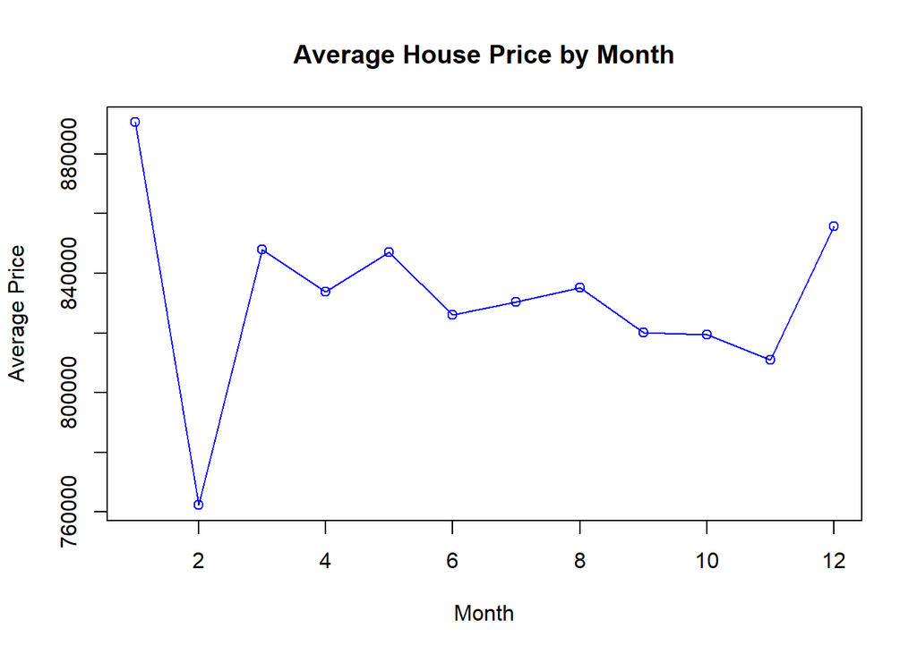

```r
#Calculate the average price for each month
monthly_avg_price <- aggregate(price ~ month, data = training_data, mean)
monthly_avg_price$month <- as.numeric(as.character(monthly_avg_price$month))
#plot
plot(monthly_avg_price$month, monthly_avg_price$price, type = "o", col = "blue",
     xlab = "Month", ylab = "Average Price", main = "Average House Price by Month")
```

```r
#Convert the 'month' and 'state' columns to factor types
training_data$month <- as.factor(training_data$month)
training_data$state <- as.factor(training_data$state)

# Calculating Average Prices
monthly_avg_price_by_state <- aggregate(price ~ state + month, data = training_data, mean)

#
monthly_avg_price_by_state <- monthly_avg_price_by_state[order(monthly_avg_price_by_state$state, monthly_avg_price_by_state$month), ]
print(monthly_avg_price_by_state)
```

```
##             state month     price
## 1     Connecticut     1  480200.8
## 10    Connecticut     2  415625.4
## 19    Connecticut     3  424920.2
## 28    Connecticut     4  409019.6
## 37    Connecticut     5  448795.8
## 46    Connecticut     6  446120.4
## 55    Connecticut     7  458672.1
## 64    Connecticut     8  574819.3
## 73    Connecticut     9  422607.1
## 82    Connecticut    10  432178.0
## 91    Connecticut    11  426104.5
## 100   Connecticut    12  450332.8
## 2           Maine     1  499819.3
## 11          Maine     2  448197.5
```

[output cut: 94 more lines]

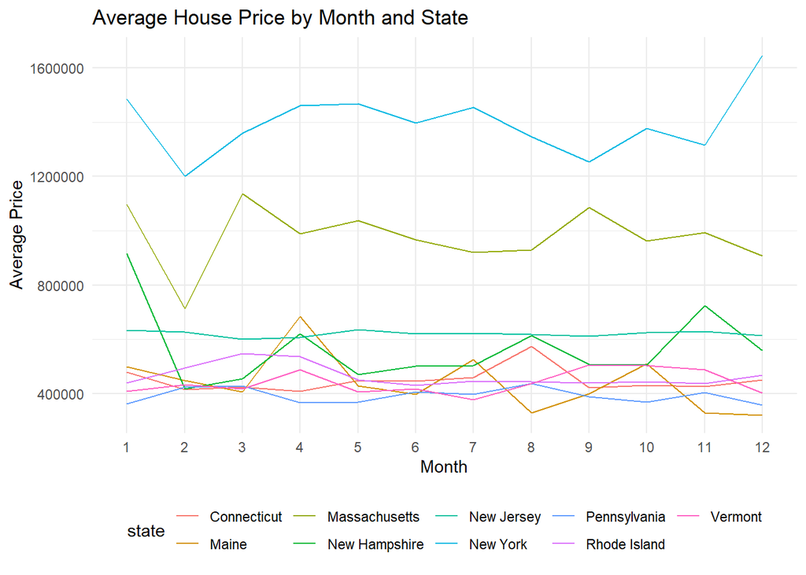

```r
#Visualizing the Data:
if(requireNamespace("ggplot2", quietly = TRUE)) {
  library(ggplot2)
  ggplot(monthly_avg_price_by_state, aes(x = month, y = price, group = state, color = state)) +
    geom_line() +
    labs(title = "Average House Price by Month and State",
         x = "Month",
         y = "Average Price") +
    theme_minimal() +
    theme(legend.position = "bottom")
}
```

```r
#Count the number of records for each state
state_counts <- table(training_data$state)

# Calculate the percentage of total records for each state
state_percentages <- round(100 * state_counts / sum(state_counts), 2)
print(state_percentages)
```

```
##
##   Connecticut         Maine Massachusetts New Hampshire    New Jersey
##         12.45          1.19         15.96          2.93         33.91
##      New York  Pennsylvania  Rhode Island       Vermont
##         25.17          2.67          3.33          2.39
```

The three states of Massachusetts, New Hampshire, and New York, like the overall average price trend, showed an early decline in February, and February was the lowest point of the whole year.There is a need to investigate whether there are external factors (such as weather conditions, economic factors, or specific policies) that may affect the housing market specific to February.

4 plot Residuals vs Fitted, Normal Q-Q, Scale-Location, Residuals vs Leverage

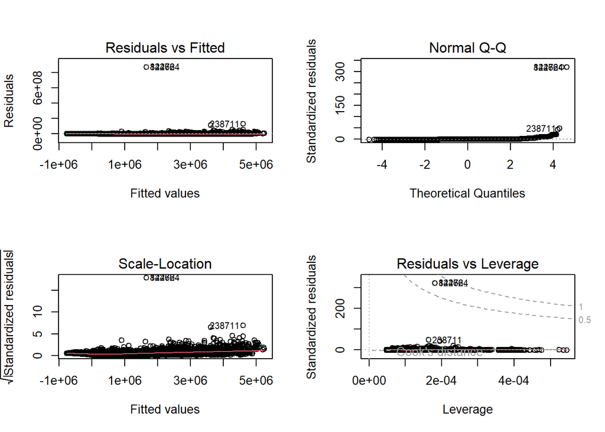

```r
par(mfrow = c(2, 2))
#Residuals vs Fitted
plot(selected_model1, which = 1)
#Normal Q-Q
plot(selected_model1, which = 2)
# Scale-Location
plot(selected_model1, which = 3)
#Residuals vs Leverage
plot(selected_model1, which = 5)
```

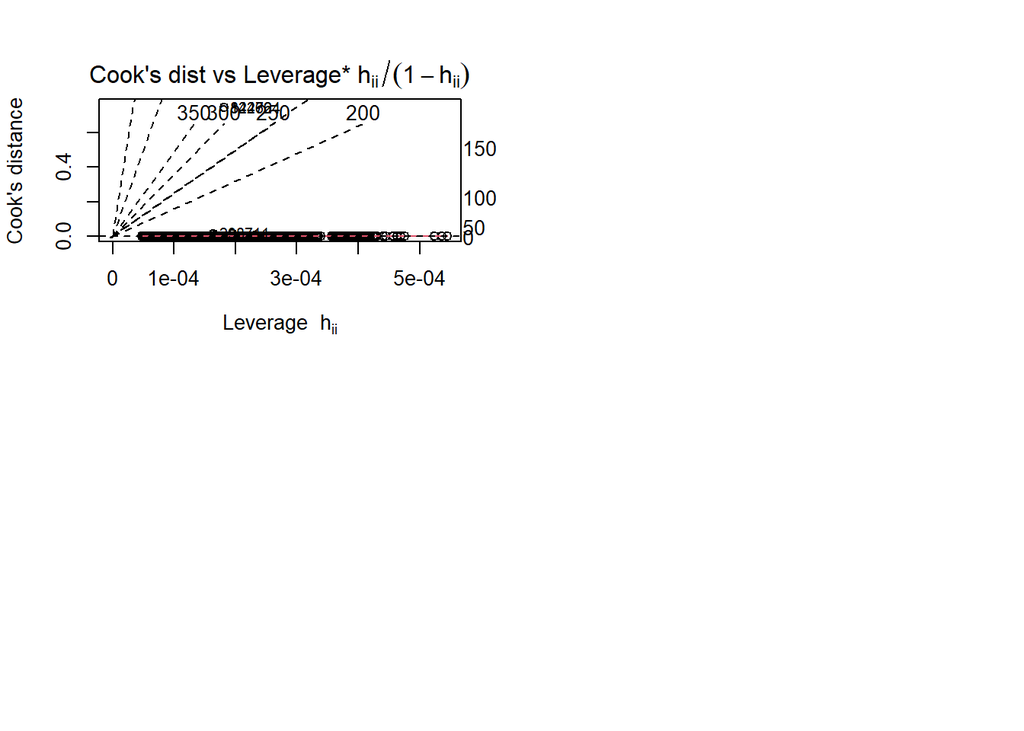

```r
#outlier vs leverage
plot(selected_model1, which = 6)
```

These residual diagnostic plots indicate that the model may violate the assumptions of homoscedasticity and normality and that there is at least one possible high-impact point. This may mean further adjustments to the model are required, such as variable transformations, adding or removing predictors

We consider starting to optimize the model(3.variable transformations, 4.adding or 5. removing predictors)

5.1 variable transformations

We draw two histograms to compare the distribution of original house prices and log-transformed house prices.

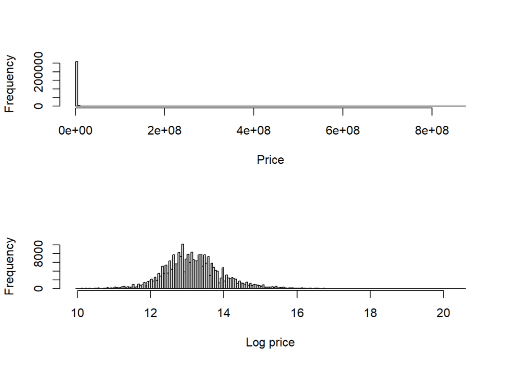

```r
# Histogram of the response variable
par(mfrow=c(2,1))
hist(training_data_selected1$price, breaks=300, xlab="Price", main="")
hist(log(training_data_selected1$price), breaks=300, xlab="Log price", main="")
```

From the comparison of histograms, logarithmic transformation seems to be an effective step. Logarithmic transformation changes the price distribution from a right-skewed distribution to look closer to a normal distribution, which can improve the fitting and prediction capabilities of the regression model.

5.2 Create a logarithmic price model

```r
library(car)
#log of price model
log_model1<-lm(log(price)~.,data=training_data_selected1)
summary(log_model1)
```

```
##
## Call:
## lm(formula = log(price) ~ ., data = training_data_selected1)
##
## Residuals:
##     Min      1Q  Median      3Q     Max
## -3.5934 -0.3166  0.0220  0.3285  6.8882
##
## Coefficients:
##                            Estimate Std. Error t value Pr(>|t|)
## (Intercept)               5.752e+00  2.526e-01  22.772  < 2e-16 ***
## year                      2.910e-03  1.256e-04  23.176  < 2e-16 ***
## stateMaine                8.489e-03  1.067e-02   0.796  0.42632
## stateMassachusetts        6.770e-01  4.260e-03 158.904  < 2e-16 ***
## stateNew Hampshire        2.267e-01  7.227e-03  31.367  < 2e-16 ***
## stateNew Jersey           3.458e-01  3.678e-03  94.025  < 2e-16 ***
## stateNew York             1.099e+00  3.983e-03 276.046  < 2e-16 ***
## statePennsylvania         6.347e-02  7.495e-03   8.469  < 2e-16 ***
## stateRhode Island         2.878e-01  6.863e-03  41.940  < 2e-16 ***
## stateVermont             -1.307e-01  7.866e-03 -16.611  < 2e-16 ***
## month2                   -2.421e-02  5.997e-03  -4.038 5.40e-05 ***
## month3                   -1.104e-03  5.758e-03  -0.192  0.84792
## month4                    5.614e-03  5.735e-03   0.979  0.32764
## month5                    2.287e-02  5.628e-03   4.064 4.83e-05 ***
## month6                    9.192e-03  5.442e-03   1.689  0.09119 .
## month7                    2.862e-02  5.405e-03   5.296 1.19e-07 ***
## month8                    1.569e-03  5.414e-03   0.290  0.77188
## month9                    3.709e-03  5.560e-03   0.667  0.50469
## month10                  -9.704e-03  5.516e-03  -1.759  0.07855 .
## month11                   1.520e-02  5.688e-03   2.673  0.00752 **
## month12                  -1.438e-03  5.572e-03  -0.258  0.79639
## house_size_filled_capped  1.193e-04  1.469e-06  81.180  < 2e-16 ***
## bed_filled_capped        -2.003e-02  1.124e-03 -17.818  < 2e-16 ***
## bath_filled_capped        3.449e-01  1.347e-03 256.053  < 2e-16 ***
## acre_lot_filled_capped    1.887e-02  2.663e-04  70.872  < 2e-16 ***
## ---
## Signif. codes:  0 '***' 0.001 '**' 0.01 '*' 0.05 '.' 0.1 ' ' 1
##
## Residual standard error: 0.5683 on 262864 degrees of freedom
## Multiple R-squared:  0.5401, Adjusted R-squared:  0.5401
## F-statistic: 1.286e+04 on 24 and 262864 DF,  p-value: < 2.2e-16
```

```r
#check for multicollinearity
vif(log_model1)
```

```
##                              GVIF Df GVIF^(1/(2*Df))
## year                     1.105336  1        1.051349
## state                    1.295782  8        1.016326
## month                    1.010141 11        1.000459
## house_size_filled_capped 1.924590  1        1.387296
## bed_filled_capped        2.160925  1        1.470008
## bath_filled_capped       2.284459  1        1.511443
## acre_lot_filled_capped   1.409167  1        1.187083
```

5.3

```r
library(MASS)
```

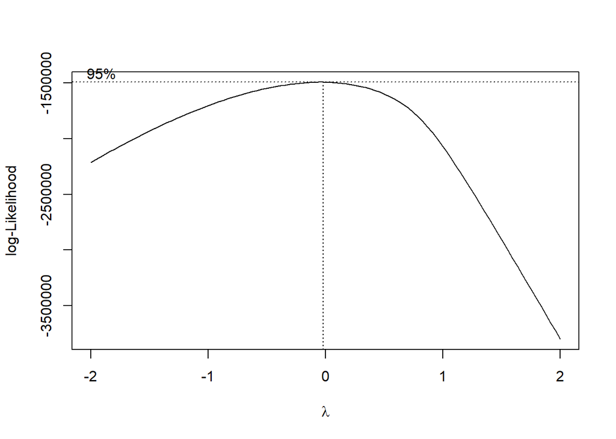

```r
bc <- boxcox(selected_model1)
```

```r
lambda <- bc$x[which.max(bc$y)]
lambda
```

```
## [1] -0.02020202
```

Since the lambda value is very close to 0, this means that the logarithmic transformation may be a suitable choice to stabilize the variance and improve model fit.

Nonetheless, model diagnostics should be continued, such as checking residuals for normality, heteroskedasticity, and other potential issues.

5.4 plot Residuals vs Fitted, Normal Q-Q, Scale-Location, Residuals vs Leverage

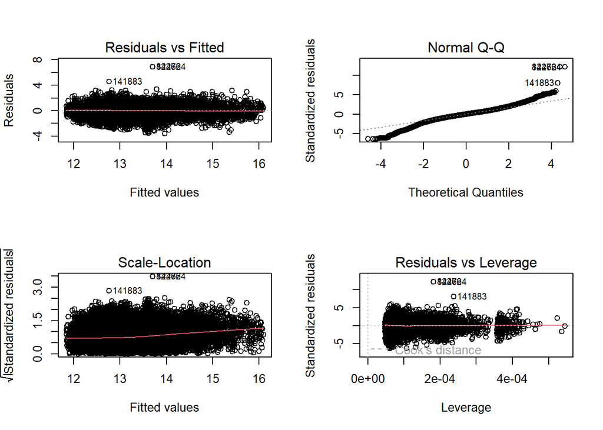

```r
par(mfrow = c(2, 2))
#Residuals vs Fitted
plot(log_model1, which = 1)
#Normal Q-Q
plot(log_model1, which = 2)
# Scale-Location
plot(log_model1, which = 3)
#Residuals vs Leverage
plot(log_model1, which = 5)
```

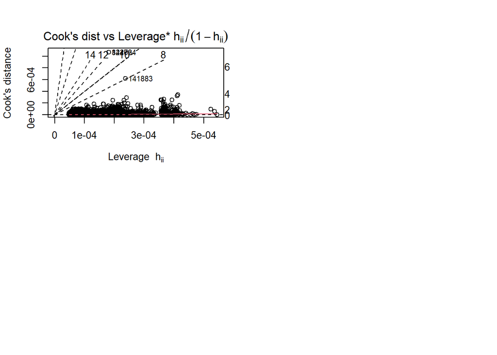

```r
#outlier vs leverage
plot(log_model1, which = 6)
```

5.5 Outlier check

```r
## Residuals versus individual predicting variables
log_model1_resid = rstandard(log_model1)
cook_log_model1 = cooks.distance(log_model1)
par(mfrow=c(2,2))
## Check outliers
influencePlot(log_model1)
```

```
##           StudRes          Hat        CookD
## 3213   -0.1555059 0.0005451262 5.275811e-07
## 15253  -0.1555059 0.0005451262 5.275811e-07
## 84262  12.1261260 0.0001810617 1.064555e-03
## 124764 12.1261260 0.0001810617 1.064555e-03
```

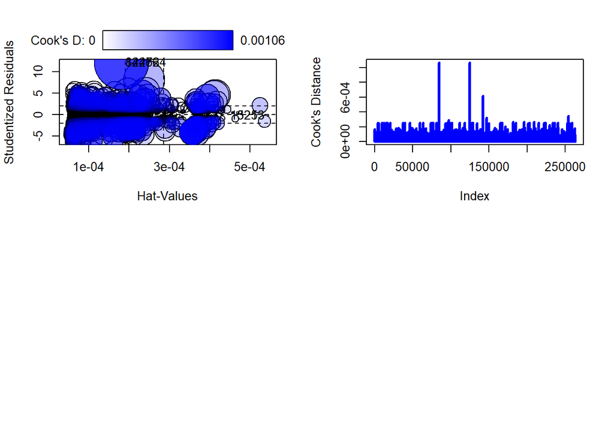

```r
plot(cook_log_model1, type="h", lwd=3, col="blue", ylab="Cook's Distance")
```

The cook’s distance is within 0.05, not significant, do not recommend to remove datapoint.

5.6

```r
## Check Normality
qqPlot(log_model1_resid, ylab="Residuals", main = "")
```

```
## [1]  84262 124764
```

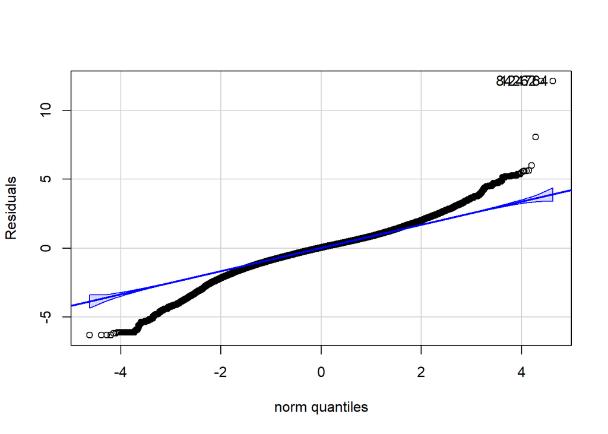

```r
qqline(log_model1_resid, col="blue", lwd=2)
```

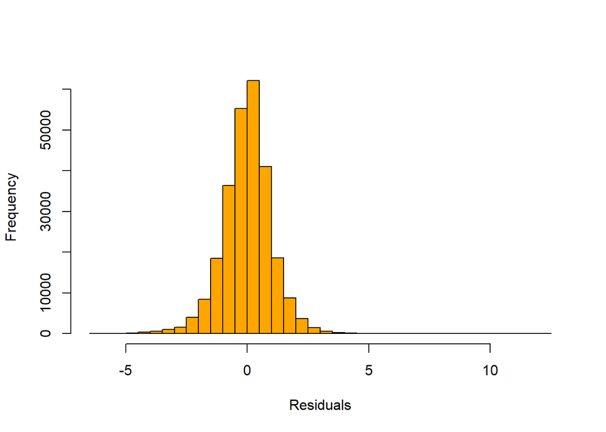

```r
hist(log_model1_resid, xlab="Residuals", main = "", nclass=30, col="orange")
```

Symmetric but heavy tailed, consider robust regression instead of least squared regression

After completing the model diagnostics, we found that the overall performance of the model is good. However, suspecting the presence of interactions, we have decided to try adding interaction terms to further improve the model.

```r
columns_to_keep2 <- c("price", "state", "year", "month", "house_size_filled_capped", "bed_filled_capped", "bath_filled_capped", "acre_lot_filled_capped", "bed/house_size_filled_capped", "bath/house_size_filled_capped", "bed_vs_bath", "bed/acre_lot_filled_capped", "bath/acre_lot_filled_capped", "house_size/acre_lot_filled_capped")
all(columns_to_keep2 %in% names(training_data))
```

```
## [1] TRUE
```

```r
training_data_selected2<-training_data[, columns_to_keep2]
training_data_selected2$state <- as.factor(training_data_selected2$state)
log_model2<-lm(log(price) ~ ., data = training_data_selected2)
summary(log_model2)
```

```
##
## Call:
## lm(formula = log(price) ~ ., data = training_data_selected2)
##
## Residuals:
##     Min      1Q  Median      3Q     Max
## -3.5996 -0.3155  0.0231  0.3262  6.8934
##
## Coefficients:
##                                       Estimate Std. Error t value Pr(>|t|)
## (Intercept)                          5.662e+00  2.521e-01  22.456  < 2e-16 ***
## stateMaine                           6.813e-03  1.063e-02   0.641   0.5218
## stateMassachusetts                   6.850e-01  4.279e-03 160.096  < 2e-16 ***
## stateNew Hampshire                   2.273e-01  7.204e-03  31.556  < 2e-16 ***
## stateNew Jersey                      3.419e-01  3.715e-03  92.052  < 2e-16 ***
## stateNew York                        1.112e+00  4.130e-03 269.157  < 2e-16 ***
## statePennsylvania                    8.797e-02  7.881e-03  11.163  < 2e-16 ***
## stateRhode Island                    2.979e-01  6.851e-03  43.484  < 2e-16 ***
## stateVermont                        -1.282e-01  7.841e-03 -16.349  < 2e-16 ***
## year                                 3.067e-03  1.253e-04  24.478  < 2e-16 ***
## month2                              -2.470e-02  5.974e-03  -4.135 3.55e-05 ***
## month3                              -1.121e-03  5.736e-03  -0.195   0.8450
## month4                               5.903e-03  5.712e-03   1.033   0.3014
## month5                               2.377e-02  5.607e-03   4.239 2.24e-05 ***
## month6                               9.551e-03  5.421e-03   1.762   0.0781 .
## month7                               2.640e-02  5.385e-03   4.901 9.52e-07 ***
## month8                               3.535e-04  5.394e-03   0.066   0.9477
## month9                               3.924e-03  5.539e-03   0.708   0.4787
## month10                             -9.025e-03  5.496e-03  -1.642   0.1005
## month11                              1.452e-02  5.666e-03   2.563   0.0104 *
## month12                             -3.477e-03  5.551e-03  -0.626   0.5311
## house_size_filled_capped             1.478e-05  3.122e-06   4.735 2.20e-06 ***
## bed_filled_capped                   -2.502e-02  2.316e-03 -10.805  < 2e-16 ***
## bath_filled_capped                   4.439e-01  3.536e-03 125.528  < 2e-16 ***
## acre_lot_filled_capped               1.760e-02  2.973e-04  59.198  < 2e-16 ***
## `bed/house_size_filled_capped`       1.716e+01  3.042e+00   5.641 1.69e-08 ***
## `bath/house_size_filled_capped`     -1.903e+02  6.153e+00 -30.930  < 2e-16 ***
## bed_vs_bathbed_less_than_bath        2.460e-02  5.104e-03   4.820 1.43e-06 ***
## bed_vs_bathbed_more_than_bath       -2.912e-02  3.800e-03  -7.663 1.82e-14 ***
## `bed/acre_lot_filled_capped`         3.958e-04  9.300e-05   4.256 2.08e-05 ***
## `bath/acre_lot_filled_capped`       -3.281e-03  1.326e-04 -24.745  < 2e-16 ***
## `house_size/acre_lot_filled_capped`  2.862e-06  1.584e-07  18.066  < 2e-16 ***
## ---
## Signif. codes:  0 '***' 0.001 '**' 0.01 '*' 0.05 '.' 0.1 ' ' 1
##
## Residual standard error: 0.566 on 262857 degrees of freedom
## Multiple R-squared:  0.5438, Adjusted R-squared:  0.5437
## F-statistic: 1.011e+04 on 31 and 262857 DF,  p-value: < 2.2e-16
```

```r
vif(log_model2)
```

```
##                                          GVIF Df GVIF^(1/(2*Df))
## state                                1.604416  8        1.029988
## year                                 1.109346  1        1.053255
## month                                1.013110 11        1.000592
## house_size_filled_capped             8.759775  1        2.959692
## bed_filled_capped                    9.242164  1        3.040093
## bath_filled_capped                  15.873722  1        3.984184
## acre_lot_filled_capped               1.770944  1        1.330768
## `bed/house_size_filled_capped`       4.686638  1        2.164864
## `bath/house_size_filled_capped`      8.068485  1        2.840508
## bed_vs_bath                          3.854224  2        1.401149
## `bed/acre_lot_filled_capped`         9.660421  1        3.108122
## `bath/acre_lot_filled_capped`       10.842738  1        3.292831
## `house_size/acre_lot_filled_capped`  8.718544  1        2.952718
```